# Part I - Loan Data From Prosper Exploration

## By Damola Babayato

- Introduction
- Preliminary Wrangling
- Univariate Exploration
- Bivariate Exploration
- Multivariate Exploration
- Conclusions

## Introduction

### Dataset Description

This data set contains 113,937 loans with 81 variables on each loan, including loan amount, borrower rate (or interest rate), current loan status, borrower income, and many others.

See this [Data Dictionary](https://www.google.com/url?q=https://docs.google.com/spreadsheet/ccc?key%3D0AllIqIyvWZdadDd5NTlqZ1pBMHlsUjdrOTZHaVBuSlE%26usp%3Dsharing&sa=D&ust=1554486256024000) to understand the dataset's variables.

## Preliminary Wrangling

```python
# import all packages and set plots to be embedded inline
import numpy as np
import pandas as pd
import matplotlib.pyplot as plt
import seaborn as sb

%matplotlib inline
```

```python
# Load the data and check the head
loan = pd.read_csv('prosperLoanData.csv')
loan.head()
```

|  | ListingKey | ListingNumber | ListingCreationDate | CreditGrade | Term | LoanStatus | ClosedDate | BorrowerAPR | BorrowerRate | LenderYield | ... | LP_ServiceFees | LP_CollectionFees | LP_GrossPrincipalLoss | LP_NetPrincipalLoss | LP_NonPrincipalRecoverypayments | PercentFunded | Recommendations | InvestmentFromFriendsCount | InvestmentFromFriendsAmount | Investors |
| --- | --- | --- | --- | --- | --- | --- | --- | --- | --- | --- | --- | --- | --- | --- | --- | --- | --- | --- | --- | --- | --- |
| 0 | 1021339766868145413AB3B | 193129 | 2007-08-26 19:09:29.263000000 | C | 36 | Completed | 2009-08-14 00:00:00 | 0.16516 | 0.1580 | 0.1380 | ... | -133.18 | 0.0 | 0.0 | 0.0 | 0.0 | 1.0 | 0 | 0 | 0.0 | 258 |
| 1 | 10273602499503308B223C1 | 1209647 | 2014-02-27 08:28:07.900000000 | NaN | 36 | Current | NaN | 0.12016 | 0.0920 | 0.0820 | ... | 0.00 | 0.0 | 0.0 | 0.0 | 0.0 | 1.0 | 0 | 0 | 0.0 | 1 |
| 2 | 0EE9337825851032864889A | 81716 | 2007-01-05 15:00:47.090000000 | HR | 36 | Completed | 2009-12-17 00:00:00 | 0.28269 | 0.2750 | 0.2400 | ... | -24.20 | 0.0 | 0.0 | 0.0 | 0.0 | 1.0 | 0 | 0 | 0.0 | 41 |
| 3 | 0EF5356002482715299901A | 658116 | 2012-10-22 11:02:35.010000000 | NaN | 36 | Current | NaN | 0.12528 | 0.0974 | 0.0874 | ... | -108.01 | 0.0 | 0.0 | 0.0 | 0.0 | 1.0 | 0 | 0 | 0.0 | 158 |
| 4 | 0F023589499656230C5E3E2 | 909464 | 2013-09-14 18:38:39.097000000 | NaN | 36 | Current | NaN | 0.24614 | 0.2085 | 0.1985 | ... | -60.27 | 0.0 | 0.0 | 0.0 | 0.0 | 1.0 | 0 | 0 | 0.0 | 20 |

5 rows × 81 columns

```python
loan.info()
```

```
<class 'pandas.core.frame.DataFrame'>
RangeIndex: 113937 entries, 0 to 113936
Data columns (total 81 columns):
 #   Column                               Non-Null Count   Dtype
---  ------                               --------------   -----
 0   ListingKey                           113937 non-null  object
 1   ListingNumber                        113937 non-null  int64
 2   ListingCreationDate                  113937 non-null  object
 3   CreditGrade                          28953 non-null   object
 4   Term                                 113937 non-null  int64
 5   LoanStatus                           113937 non-null  object
 6   ClosedDate                           55089 non-null   object
 7   BorrowerAPR                          113912 non-null  float64
 8   BorrowerRate                         113937 non-null  float64
 9   LenderYield                          113937 non-null  float64
```

[output cut: 73 more lines]

Due to the high amount of features, I am going to subset the data to area of interests. I am going to select only the columns that are related to our exploration of the loan. These columns are related to the amount of loan, dates, rates and other characteristics about the borrowers.

```python
df_loan = loan.loc[:, ['BorrowerRate', 'LenderYield', 'ProsperRating (Alpha)', 'ProsperScore',
                        'ListingCreationDate', 'Term', 'LoanStatus', 'ClosedDate', 'BorrowerAPR',
                         'BorrowerState', 'Occupation', 'EmploymentStatus', 'AmountDelinquent',
                         'MonthlyLoanPayment', 'LP_ServiceFees', 'Investors','ListingCategory (numeric)',
                         'IncomeRange', 'StatedMonthlyIncome','LoanCurrentDaysDelinquent',
                         'LoanOriginalAmount', 'LoanOriginationDate', 'ListingCategory (numeric)',
                         'CreditScoreRangeLower', 'CreditScoreRangeUpper']]
df_loan.head()
```

|  | BorrowerRate | LenderYield | ProsperRating (Alpha) | ProsperScore | ListingCreationDate | Term | LoanStatus | ClosedDate | BorrowerAPR | BorrowerState | ... | Investors | ListingCategory (numeric) | IncomeRange | StatedMonthlyIncome | LoanCurrentDaysDelinquent | LoanOriginalAmount | LoanOriginationDate | ListingCategory (numeric) | CreditScoreRangeLower | CreditScoreRangeUpper |
| --- | --- | --- | --- | --- | --- | --- | --- | --- | --- | --- | --- | --- | --- | --- | --- | --- | --- | --- | --- | --- | --- |
| 0 | 0.1580 | 0.1380 | NaN | NaN | 2007-08-26 19:09:29.263000000 | 36 | Completed | 2009-08-14 00:00:00 | 0.16516 | CO | ... | 258 | 0 | $25,000-49,999 | 3083.333333 | 0 | 9425 | 2007-09-12 00:00:00 | 0 | 640.0 | 659.0 |
| 1 | 0.0920 | 0.0820 | A | 7.0 | 2014-02-27 08:28:07.900000000 | 36 | Current | NaN | 0.12016 | CO | ... | 1 | 2 | $50,000-74,999 | 6125.000000 | 0 | 10000 | 2014-03-03 00:00:00 | 2 | 680.0 | 699.0 |
| 2 | 0.2750 | 0.2400 | NaN | NaN | 2007-01-05 15:00:47.090000000 | 36 | Completed | 2009-12-17 00:00:00 | 0.28269 | GA | ... | 41 | 0 | Not displayed | 2083.333333 | 0 | 3001 | 2007-01-17 00:00:00 | 0 | 480.0 | 499.0 |
| 3 | 0.0974 | 0.0874 | A | 9.0 | 2012-10-22 11:02:35.010000000 | 36 | Current | NaN | 0.12528 | GA | ... | 158 | 16 | $25,000-49,999 | 2875.000000 | 0 | 10000 | 2012-11-01 00:00:00 | 16 | 800.0 | 819.0 |
| 4 | 0.2085 | 0.1985 | D | 4.0 | 2013-09-14 18:38:39.097000000 | 36 | Current | NaN | 0.24614 | MN | ... | 20 | 2 | $100,000+ | 9583.333333 | 0 | 15000 | 2013-09-20 00:00:00 | 2 | 680.0 | 699.0 |

5 rows × 25 columns

```python
# check the info
df_loan.info()
```

```
<class 'pandas.core.frame.DataFrame'>
RangeIndex: 113937 entries, 0 to 113936
Data columns (total 25 columns):
 #   Column                     Non-Null Count   Dtype
---  ------                     --------------   -----
 0   BorrowerRate               113937 non-null  float64
 1   LenderYield                113937 non-null  float64
 2   ProsperRating (Alpha)      84853 non-null   object
 3   ProsperScore               84853 non-null   float64
 4   ListingCreationDate        113937 non-null  object
 5   Term                       113937 non-null  int64
 6   LoanStatus                 113937 non-null  object
 7   ClosedDate                 55089 non-null   object
 8   BorrowerAPR                113912 non-null  float64
 9   BorrowerState              108422 non-null  object
```

[output cut: 17 more lines]

```python
#description of the numeric columns in dataset
df_loan.describe()
```

|  | BorrowerRate | LenderYield | ProsperScore | Term | BorrowerAPR | AmountDelinquent | MonthlyLoanPayment | LP_ServiceFees | Investors | ListingCategory (numeric) | StatedMonthlyIncome | LoanCurrentDaysDelinquent | LoanOriginalAmount | ListingCategory (numeric) | CreditScoreRangeLower | CreditScoreRangeUpper |
| --- | --- | --- | --- | --- | --- | --- | --- | --- | --- | --- | --- | --- | --- | --- | --- | --- |
| count | 113937.000000 | 113937.000000 | 84853.000000 | 113937.000000 | 113912.000000 | 106315.000000 | 113937.000000 | 113937.000000 | 113937.000000 | 113937.000000 | 1.139370e+05 | 113937.000000 | 113937.00000 | 113937.000000 | 113346.000000 | 113346.000000 |
| mean | 0.192764 | 0.182701 | 5.950067 | 40.830248 | 0.218828 | 984.507059 | 272.475783 | -54.725641 | 80.475228 | 2.774209 | 5.608026e+03 | 152.816539 | 8337.01385 | 2.774209 | 685.567731 | 704.567731 |
| std | 0.074818 | 0.074516 | 2.376501 | 10.436212 | 0.080364 | 7158.270157 | 192.697812 | 60.675425 | 103.239020 | 3.996797 | 7.478497e+03 | 466.320254 | 6245.80058 | 3.996797 | 66.458275 | 66.458275 |
| min | 0.000000 | -0.010000 | 1.000000 | 12.000000 | 0.006530 | 0.000000 | 0.000000 | -664.870000 | 1.000000 | 0.000000 | 0.000000e+00 | 0.000000 | 1000.00000 | 0.000000 | 0.000000 | 19.000000 |
| 25% | 0.134000 | 0.124200 | 4.000000 | 36.000000 | 0.156290 | 0.000000 | 131.620000 | -73.180000 | 2.000000 | 1.000000 | 3.200333e+03 | 0.000000 | 4000.00000 | 1.000000 | 660.000000 | 679.000000 |
| 50% | 0.184000 | 0.173000 | 6.000000 | 36.000000 | 0.209760 | 0.000000 | 217.740000 | -34.440000 | 44.000000 | 1.000000 | 4.666667e+03 | 0.000000 | 6500.00000 | 1.000000 | 680.000000 | 699.000000 |
| 75% | 0.250000 | 0.240000 | 8.000000 | 36.000000 | 0.283810 | 0.000000 | 371.580000 | -13.920000 | 115.000000 | 3.000000 | 6.825000e+03 | 0.000000 | 12000.00000 | 3.000000 | 720.000000 | 739.000000 |
| max | 0.497500 | 0.492500 | 11.000000 | 60.000000 | 0.512290 | 463881.000000 | 2251.510000 | 32.060000 | 1189.000000 | 20.000000 | 1.750003e+06 | 2704.000000 | 35000.00000 | 20.000000 | 880.000000 | 899.000000 |

```python
df_loan.duplicated().sum()
```

```
0
```

```python
df_loan.isnull().sum()
```

```
BorrowerRate                     0
LenderYield                      0
ProsperRating (Alpha)        29084
ProsperScore                 29084
ListingCreationDate              0
Term                             0
LoanStatus                       0
ClosedDate                   58848
BorrowerAPR                     25
BorrowerState                 5515
Occupation                    3588
EmploymentStatus              2255
AmountDelinquent              7622
MonthlyLoanPayment               0
LP_ServiceFees                   0
Investors                        0
ListingCategory (numeric)        0
IncomeRange                      0
StatedMonthlyIncome              0
LoanCurrentDaysDelinquent        0
LoanOriginalAmount               0
LoanOriginationDate              0
ListingCategory (numeric)        0
CreditScoreRangeLower          591
CreditScoreRangeUpper          591
dtype: int64
```

```python
#Change Datetime columns
df_loan['ListingCreationDate'] = pd.to_datetime(df_loan['ListingCreationDate'])
df_loan['ClosedDate'] = pd.to_datetime(df_loan['ClosedDate'])
df_loan['LoanOriginationDate'] = pd.to_datetime(df_loan['LoanOriginationDate'])
```

```python
# Convert ProsperRating & IncomeRange to categorical
cat_columns = {'ProsperRating (Alpha)': ['N/A','HR','E','D','C', 'B', 'A', 'AA'],
                    'IncomeRange':['$0','$1-24,999','$25,000-49,999','$50,000-74,999','$75,000-99,999','$100,000+']}

for col in cat_columns:
    cat_col = pd.api.types.CategoricalDtype(ordered = True, categories = cat_columns[col])
    df_loan[col] = df_loan[col].astype(cat_col)
```

```python
# Change dataype for other categorical columns
df_loan['BorrowerState'] = df_loan['BorrowerState'].astype('category')
df_loan['LoanStatus'] = df_loan['LoanStatus'].astype('category')
df_loan['ListingCategory (numeric)'] = df_loan['ListingCategory (numeric)'].astype('category')
df_loan['EmploymentStatus'] = df_loan['EmploymentStatus'].astype('category')
df_loan['Occupation'] = df_loan['Occupation'].astype('category')
```

```python
df_loan.shape
```

```
(113937, 25)
```

```python
df_loan.info()
```

```
<class 'pandas.core.frame.DataFrame'>
RangeIndex: 113937 entries, 0 to 113936
Data columns (total 25 columns):
 #   Column                     Non-Null Count   Dtype
---  ------                     --------------   -----
 0   BorrowerRate               113937 non-null  float64
 1   LenderYield                113937 non-null  float64
 2   ProsperRating (Alpha)      84853 non-null   category
 3   ProsperScore               84853 non-null   float64
 4   ListingCreationDate        113937 non-null  datetime64[ns]
 5   Term                       113937 non-null  int64
 6   LoanStatus                 113937 non-null  category
 7   ClosedDate                 55089 non-null   datetime64[ns]
 8   BorrowerAPR                113912 non-null  float64
 9   BorrowerState              108422 non-null  category
```

[output cut: 17 more lines]

### What is the structure of your dataset?

The dataset contains 113937 rows and 25 columns. Majority of the columns are numeric but we also have categorical variables and datetime variables.

### What is/are the main feature(s) of interest in your dataset?

The main interest of exploring this dataset would be the Loan Original Amount. I will also work on Borrower Rate, Borrower APR, Prosper Score, CreditScoreRangeLower, CreditScoreRangeUpper, Borrower Occupation, Borrower State etc.

### What features in the dataset do you think will help support your investigation into your feature(s) of interest?

I believe borrower's Loan Status and Employment Status will have a strong impact on loan and the features we are trying to explore. Also the Income Range can be a pointer here and the Term (lenght of the loan) may have an effect.

## Univariate Exploration

> For this phase, we would be exploring the different variables in the dataset to see how they're distributed, their absolute frequencies and to generally understand their relevance in the entire exploration.

```python
# creating a function for chart name, x and y labels, to avoid repetition in using the plt function
def labels(a,b,c):
    """
    This function gives chart title, x and y axis
    --------
    It aims to avoid repetition by taking in three parameters for the chart title and both the x and y axis labels
    """
    return plt.title(a),plt.ylabel(b),plt.xlabel(c)
```

### Question 1

What is the Borrower APR (Annual Percentage Rate) distribution?

### Visualization

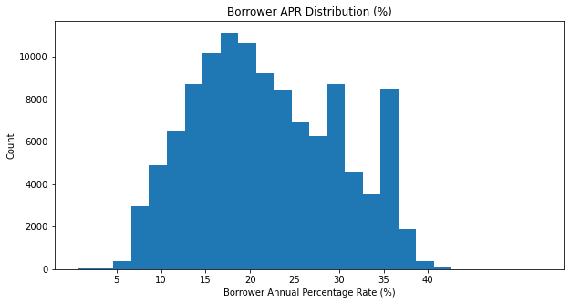

```python
# Distribution of Borrower APR in percentage
BorrowerAPR_pct = df_loan['BorrowerAPR']*100
bins = np.arange(df_loan['BorrowerAPR'].min()*100, df_loan['BorrowerAPR'].max()*100+2, 2)

plt.figure(figsize=[10, 5])
plt.hist(x = BorrowerAPR_pct, bins = bins)
plt.xticks([5, 10, 15, 20, 25, 30, 35, 40], ['5','10', '15', '20', '25', '30', '35', '40'])
labels('Borrower APR Distribution (%)','Count','Borrower Annual Percentage Rate (%)');
```

### Observation

We can infer that the Borrower APR is normally distrubuted with a peak between 15% and 20% in addition we have some increase in the 35%.

### Question 2

What is the Loan Original Amount distribution?

### Visualization

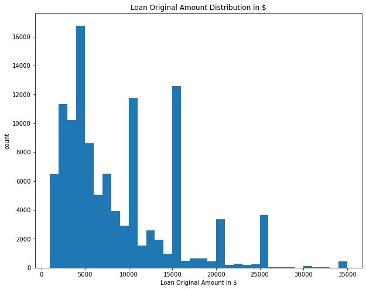

```python
# Loan Original Amount Distribution
bins = np.arange(df_loan['LoanOriginalAmount'].min(), df_loan['LoanOriginalAmount'].max()+1000, 1000)

plt.figure(figsize=[10, 8])
plt.hist(data = df_loan, x = 'LoanOriginalAmount', bins = bins)
labels('Loan Original Amount Distribution in $','count','Loan Original Amount in $');
```

### Observation

We see that the distribution is right skewed with a long tail so we will transform to a log scale for clearer insight.

```python
# Transform the describe() to a scale of log10
np.log10(df_loan['LoanOriginalAmount'].describe())
```

```
count    5.056665
mean     3.921011
std      3.795588
min      3.000000
25%      3.602060
50%      3.812913
75%      4.079181
max      4.544068
Name: LoanOriginalAmount, dtype: float64
```

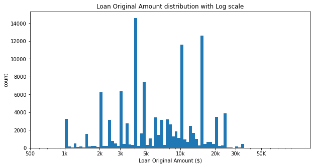

```python
# Putting Loan Original Amount in a log-scale
bins = 10 ** np.arange(3, 5+0.025, 0.025)

# Generate the x-ticks you want to apply
ticks = [500, 1e3, 2e3,3e3, 5e3, 1e4, 2e4, 3e4, 5e4]

plt.figure(figsize=[10, 5])
plt.hist(data = df_loan, x = 'LoanOriginalAmount', bins = bins)
plt.xscale('log')
labels('Loan Original Amount distribution with Log scale','count','Loan Original Amount ($)');
# Apply x-ticks
plt.xticks(ticks, labels=['500', '1k', '2k', '3k', '5k', '10k', '20k', '30k', '50K']);
```

### Observation

We can see that the highest value for original loan amount is between 3K and 5K. Also I noticed an increase in amount between 10K and 20K.

### Question 3

What different loan terms are there, what are their frequencies?

### Visualization

```python
df_loan['Term'].value_counts()
```

```
36    87778
60    24545
12     1614
Name: Term, dtype: int64
```

We can see that in years terms can be either 1 year (12 month) or 3 years (36 months) or 5 years (60 months).

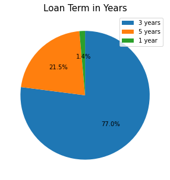

```python
pie_data = df_loan.Term.value_counts()
plt.figure(figsize=(10,5))
plt.pie(pie_data, autopct='%1.1f%%', startangle=90, counterclock=False)
plt.title('Loan Term in Years', fontsize=15)
plt.legend(labels=['3 years','5 years','1 year']);
```

### Observation

We can infer that most of the loans taken were for 3 years(36 months) with a 77%, while 12 months loan had the least frequency with 1.4%. With some loans being for 5 years(60 months).

### Question 4

What is the Proper Score disribution?

- ProsperScore: A custom risk score built using historical Prosper data. The score ranges from 1-10, with 10 being the best, or lowest risk score.

### Visualization

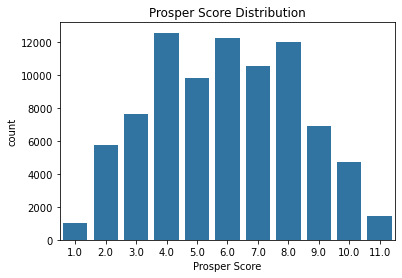

```python
base_color = sb.color_palette()[0]
sb.countplot(data=df_loan, x= 'ProsperScore', color=base_color)
labels('Prosper Score Distribution','count','Prosper Score');
```

### Observation

We can see a modal score of 4 and we can tell that most borrowers fall within 4-8 risk score. Also we can infer that borrowers with the highest risk score of 1 are the least population in the dataset. Another observation is a category of borrowers having a risk score of 11 whereas the prosper score ranges from 0-10. This could be as a result of incorrect data.

### Question 5

In which caterogy is the reason why loans was taken?

- ListingCategory: The category of the listing that the borrower selected when posting their listing: 0 - Not Available, 1 - Debt Consolidation, 2 - Home Improvement, 3 - Business, 4 - Personal Loan, 5 - Student Use, 6 - Auto, 7- Other, 8 - Baby&Adoption, 9 - Boat, 10 - Cosmetic Procedure, 11 - Engagement Ring, 12 - Green Loans, 13 - Household Expenses, 14 - Large Purchases, 15 - Medical/Dental, 16 - Motorcycle, 17 - RV, 18 - Taxes, 19 - Vacation, 20 - Wedding Loans

### Visualization

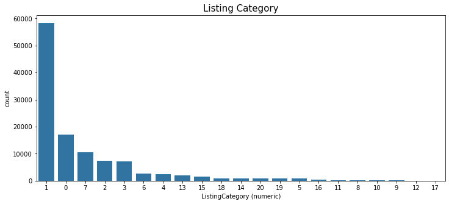

```python
plt.figure(figsize=(12,5))
order = loan['ListingCategory (numeric)'].value_counts().index
sb.countplot(data=loan, x='ListingCategory (numeric)', color=base_color, order=order)
plt.xlabel('ListingCategory (numeric)')
plt.title('Listing Category',fontsize=15);
```

### Observation

We see that Debt Consolidation is the major reason why people take out new loans. Home improvement loans and Business loans trail behind some loans termed 'Other' or 'Not available' to signify that the borrower didn't specify their reason. Green loans and loans for boats and RVs were the least types of listings created. People also took out loans to get engagement rings.

### Question 6

What is the distribution of Lender Yield on the loan?

### Visualization

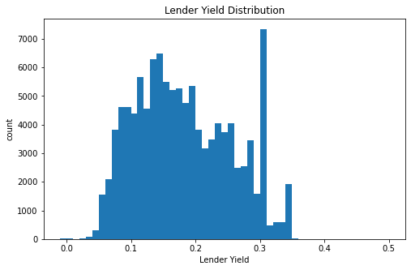

```python
bins = np.arange(df_loan['LenderYield'].min(), df_loan['LenderYield'].max()+0.01,0.01)

plt.figure(figsize=[8, 5])
plt.hist(data = df_loan, x = 'LenderYield', bins = bins)
labels('Lender Yield Distribution','count','Lender Yield');
```

### Observation

We see that Lender Yield is nomarlly distributed with most of the interest rate on the loan between 0.1 and 0.2 and we notice an increase at 0.3.

### Question 7

What is the amount deliquency distribution?

### Visualization

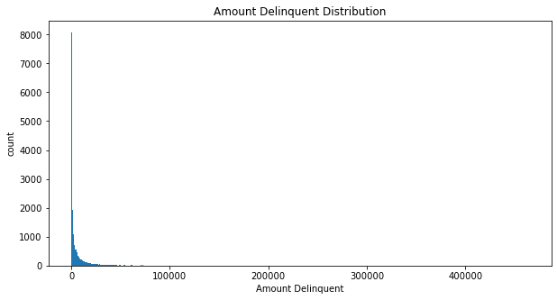

```python
bins = np.arange(df_loan['AmountDelinquent'].min(), df_loan['AmountDelinquent'].max()+1000, 1000)

plt.figure(figsize=[10, 5])
plt.hist(data = df_loan[df_loan['AmountDelinquent']>0], x = 'AmountDelinquent', bins = bins)
labels('Amount Delinquent Distribution','count','Amount Delinquent');
```

```python
df_loan['AmountDelinquent'].value_counts()
```

```
0.0        89818
50.0          73
100.0         67
25.0          66
30.0          65
           ...
14910.0        1
1280.0         1
13180.0        1
2023.0         1
5062.0         1
Name: AmountDelinquent, Length: 7059, dtype: int64
```

We can see that Amount Delinquent is right skewed and no meaningful insights can be derived from this. So we will perform a log scale transformation. Also, most of the loans do not have delinquence as we saw that at 0 we have 89818. It is better checking this in log-scale

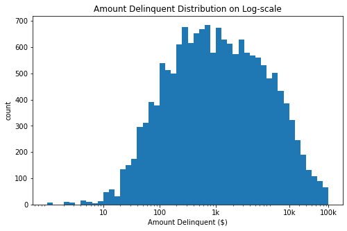

```python
# Putting Amount Delinquent in a log-scale
bins = 10 ** np.arange(0,5+0.1,0.1)
# Generate the x-ticks you want to apply
ticks = [1e1, 1e2, 1e3, 2e4, 1e5]

plt.figure(figsize=[8, 5])
plt.hist(data = df_loan, x = 'AmountDelinquent', bins = bins)
plt.xscale('log')
labels('Amount Delinquent Distribution on Log-scale','count','Amount Delinquent ($)')
# Apply x-ticks
plt.xticks(ticks, labels =['10', '100', '1k', '10k', '100k']);
```

### Observation

We can infer that most amount delinquent falls around $1000 and it is normally distibuted.

### Question 8

What is the Monthly Loan Payment distribution?

### Visualization

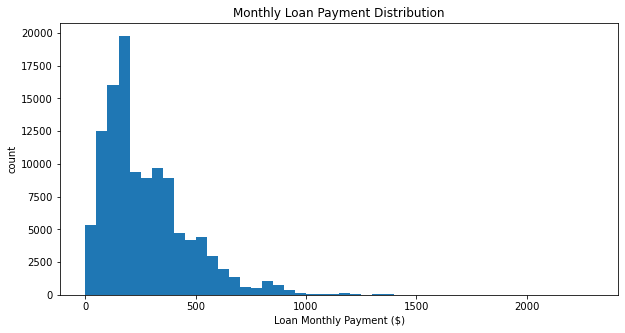

```python
bins = np.arange(0, df_loan['MonthlyLoanPayment'].max()+50, 50)

plt.figure(figsize=[10, 5])
plt.hist(data = df_loan, x = 'MonthlyLoanPayment', bins = bins)
labels('Monthly Loan Payment Distribution','count','Loan Monthly Payment ($)');
```

### Observation

We see that the distribution is right skewed with a long tail so we will transform to a log scale for clearer insight.

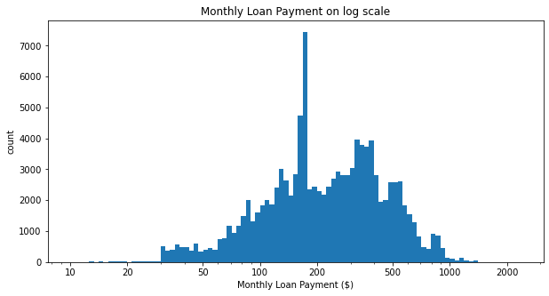

```python
# Putting the Monthly Loan Payment in a log-scale
bins = 10 ** np.arange(1, np.log10(df_loan['MonthlyLoanPayment'].max())+0.025, 0.025)
# Generate the x-ticks you want to apply
ticks = [10, 20, 50, 100, 200, 500, 1e3, 2e3]
plt.figure(figsize=[10, 5])
plt.hist(data = df_loan, x = 'MonthlyLoanPayment', bins = bins)
plt.xscale('log')
labels('Monthly Loan Payment on log scale','count','Monthly Loan Payment ($)')
# Apply x-ticks
plt.xticks(ticks, labels=['10', '20','50', '100', '200', '500', '1000', '2000']);
```

### Observation

We can see we have attained a normal distribution with the peak between 100 and 200 and some increase at the 500.

### Question 9

What states are the most borrowers from?

### Visualization

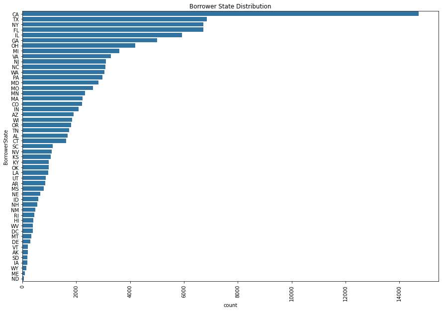

```python
plt.figure(figsize=(15,10))
order = df_loan['BorrowerState'].value_counts().index
sb.countplot(data=loan, y='BorrowerState', color=base_color, order=order)
plt.title('Borrower State Distribution');
plt.xticks(rotation=90);
```

### Observation

We can see that California (CA) has the highest amount of borrowers by a wide margin, Texas (TX) and New York (NY) follow suit while North Dakota, Maine and Wyoming have the lowest count of borrowers.

### Question 11

Which occupation has the highest loan takers?

### Visualization

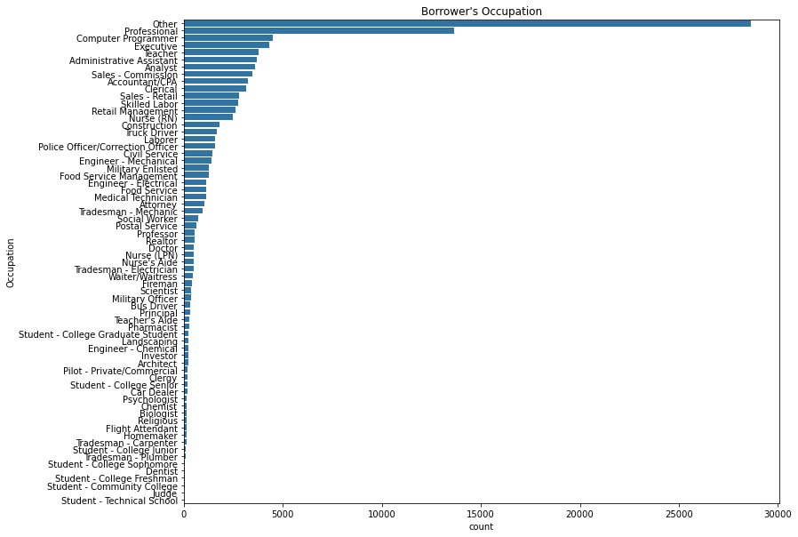

```python
plt.figure(figsize=(12,10))
order = df_loan.Occupation.value_counts().index
sb.countplot(data=df_loan, y='Occupation', color=base_color, order=order)
labels('Borrower\'s Occupation','Occupation','count');
```

### Observation

We can see that a large number of borrowers specified their Occupation to be 'Others'. The most common occupations thereof are Professionals, Computer Programmers and Executives. At the bottom of the list we have students in Techincal School and College Freshman Students and also Judges. Are judges are afraid of facing the law if they don't pay back their loans?

### Question 11

What kind of employment do the people who take the most loans have?

### Visualization

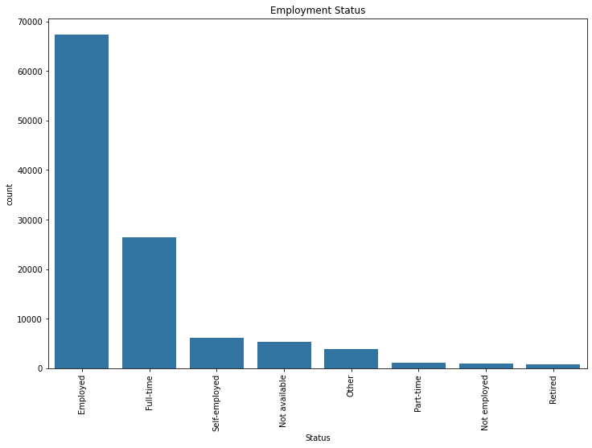

```python
plt.figure(figsize=(12,8))
order = loan.EmploymentStatus.value_counts().index
sb.countplot(data=loan, x='EmploymentStatus', color=base_color, order=order)
plt.title('Employment Status')
plt.xlabel('Status')
plt.xticks(rotation='90');
```

### Observation

We can infer that though the borrowers are employed, they are the group that took the most loans while unemployed or retired people take the least loans.

### Question 12

What is the income range of borrowers ?

### Visualization

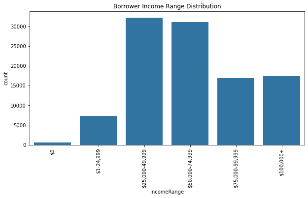

```python
plt.figure(figsize=[10, 5])
sb.countplot(data=df_loan,x='IncomeRange',color=base_color);
plt.title('Borrower Income Range Distribution');
plt.xticks(rotation=90);
```

### Observation

We can see that people with income range of $25,000-49,999 are the ones who are taking loans the most. Income doesn't seem to play a role in why people take out loans as even people who earn over 100k still make up a huge part of the population.

### Question 13

Which people within what credit score range are most likely to take out loans?

### Visualization

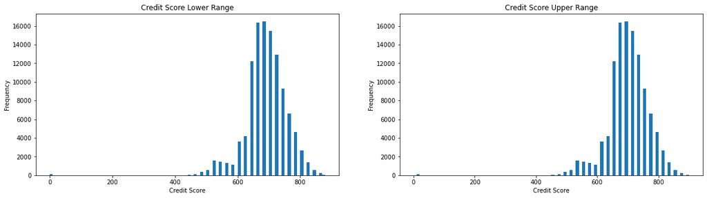

```python
plt.figure(figsize = [20, 5])

bins = np.arange(0, df_loan['CreditScoreRangeLower'].max()+10, 10)
plt.subplot(1,2,1)
plt.hist(data=df_loan, x='CreditScoreRangeLower', bins=bins)
labels('Credit Score Lower Range','Frequency','Credit Score');


bins = np.arange(0, df_loan['CreditScoreRangeUpper'].max()+10, 10)
plt.subplot(1,2,2)
plt.hist(data=df_loan, x='CreditScoreRangeUpper', bins=bins)
labels('Credit Score Upper Range','Frequency','Credit Score');
```

### Observation

We can see that the range for most borrower falls between 650-750.

### Question 14

What are the different loan status and its distribution?

### Visualization

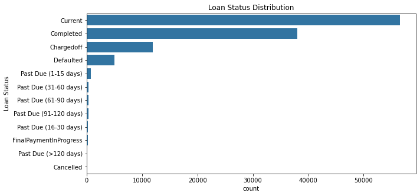

```python
plt.figure(figsize=(10,5))
order = df_loan['LoanStatus'].value_counts().index
sb.countplot(data=df_loan, y='LoanStatus', color=base_color, order=order)
labels('Loan Status Distribution','Loan Status','count');
```

### Observation

We can see that majority of the listings are still current loans, although a huge number of the loan listings have been completed. Only a few are past behind on payment. Some have defaulted, while others have even been charged off due to defaulting. We can also note that people rarely cancel their loan listings as that category has the lowest frequency.

### Discuss the distribution(s) of your variable(s) of interest. Were there any unusual points? Did you need to perform any transformations?

Loan Original Amount distribution is right skewed and I performed log transformation on it to interpret the visualization. I also did the log transformation to these variables: Monthly Loan Payment and Amount Delinquent.

An unusual pointer was that the reason people took out loans was expected to be either their Income Range or Employment Status but surprisingly the charts showed otherwise, as people who earned over 100k still made up a large % of the population and people who are employed took out more loans than the business people. The only wrangling needed to be done would be to drop the numerous columns that we won't be needing for our exploration in the next phase. This would enable us work with the dataset more effectively and get rid of too much information.

### Of the features you investigated, were there any unusual distributions? Did you perform any operations on the data to tidy, adjust, or change the form of the data? If so, why did you do this?

Also, due to the high difference between AmountDelinquent values the distribution was really on large scale and I couldn't see it clear so I did the log transformation. Some features had long-tailed, skewed distributions, these were checked on a log scale to show the hidden distribution in some areas.

## Bivariate Exploration

> For the Bivariate Exploration, we would be comparing two variables and trying to see whether there is a correlation between them.

```python
df_loan.info()
```

```
<class 'pandas.core.frame.DataFrame'>
RangeIndex: 113937 entries, 0 to 113936
Data columns (total 25 columns):
 #   Column                     Non-Null Count   Dtype
---  ------                     --------------   -----
 0   BorrowerRate               113937 non-null  float64
 1   LenderYield                113937 non-null  float64
 2   ProsperRating (Alpha)      84853 non-null   category
 3   ProsperScore               84853 non-null   float64
 4   ListingCreationDate        113937 non-null  datetime64[ns]
 5   Term                       113937 non-null  int64
 6   LoanStatus                 113937 non-null  category
 7   ClosedDate                 55089 non-null   datetime64[ns]
 8   BorrowerAPR                113912 non-null  float64
 9   BorrowerState              108422 non-null  category
```

[output cut: 17 more lines]

```python
# Identify numeric features
num_cols = ['StatedMonthlyIncome', 'LoanOriginalAmount', 'MonthlyLoanPayment','AmountDelinquent',
            'LoanCurrentDaysDelinquent','Term',
            'BorrowerAPR', 'BorrowerRate', 'LenderYield', 'ProsperScore']
```

### Correlation Matrix

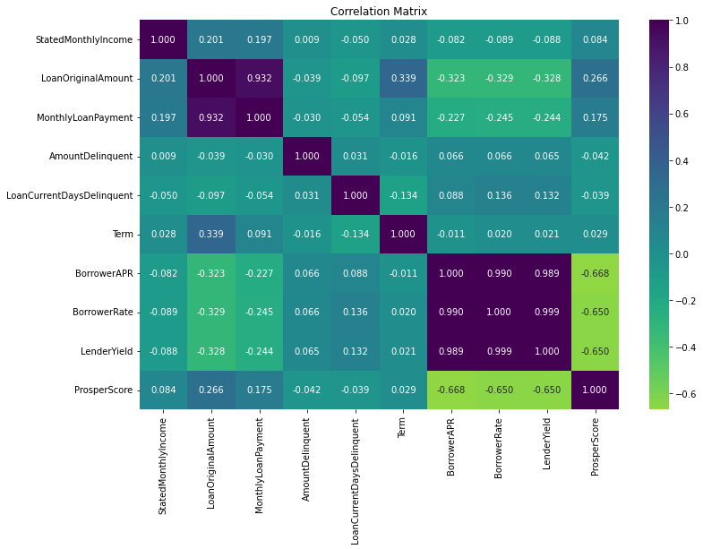

```python
plt.figure(figsize = [12, 8])
sb.heatmap(df_loan[num_cols].corr(), annot = True, fmt = '.3f',
           cmap = 'viridis_r', center = 0)
plt.title('Correlation Matrix');
```

We can see :

- Strong positive correlations between Lender yield and Borrower Rate with Borrower APR. Loan original amount and Monthly Loan Payment are also in positive correlation.
- Negative correlation between Prosper Score & Borrower APR, and Prosper Score & Lender yield. Also We see negative relationship between Loan Original Amount and Borrower APR, means large loans have relatively less annual interest rate from the borrower.

### Question 15

What is the Borrower's APR on Loan Status and Employment Status?

### Visualization

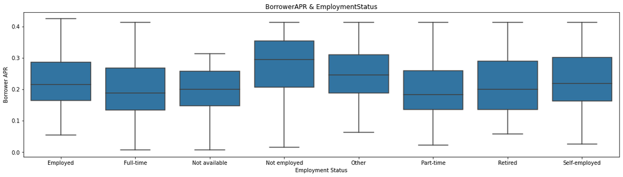

```python
# Borrower APR vs Employment status
plt.figure(figsize = (20, 5))

sb.boxplot(data=df_loan,y='BorrowerAPR',x='EmploymentStatus',color=base_color);
labels('BorrowerAPR & EmploymentStatus','Borrower APR','Employment Status');
```

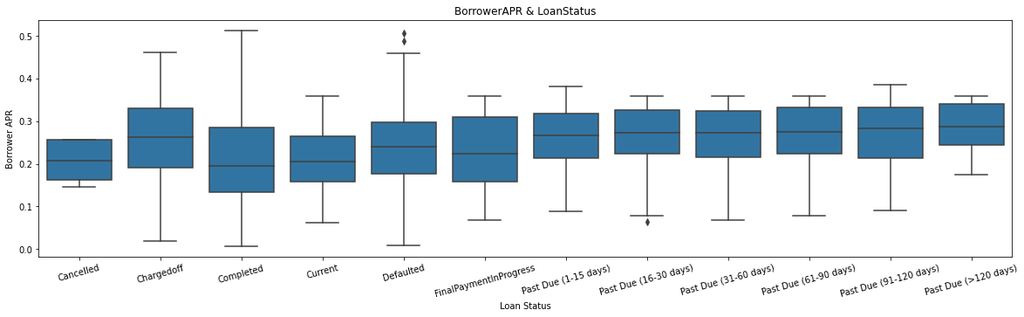

```python
# Borrower APR vs Status of Loan
plt.figure(figsize = (20, 5))
sb.boxplot(data=df_loan,y='BorrowerAPR',x='LoanStatus',color=base_color);
labels('BorrowerAPR & LoanStatus','Borrower APR','Loan Status')
plt.xticks(rotation=15);
```

### Observation

We can infer that people who are employed have lower APR than people who are not employed. Also we can see that current and completed loans have lower rate than the past-due loans and have lower mean.

### Question 16

Does high risk prosper score yield more loans than low risk score?

### Visualization

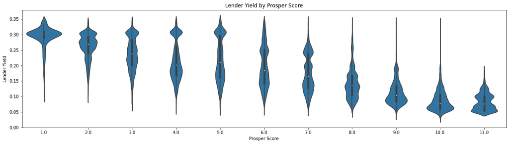

```python
plt.figure(figsize = (20, 5))
sb.violinplot(data=df_loan,x='ProsperScore',y='LenderYield',color=base_color);
labels('Lender Yield by Prosper Score','Lender Yield','Prosper Score');
```

### Observation

We can see that Prosper loans with high risk factor (prosper score of 1) yields more loans than low risk factor (prosper score of 10).

### Question 17

Does the Income Range of the borrower affect the Loan Original Amount i.e the amount the borrower can get as a loan?

### Visualization

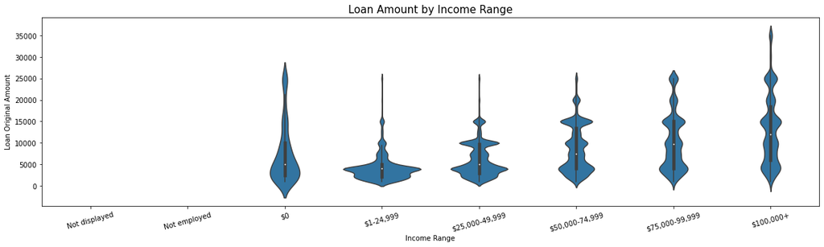

```python
plt.figure(figsize=(20,5))
order = ['Not displayed','Not employed','$0','$1-24,999','$25,000-49,999','$50,000-74,999','$75,000-99,999','$100,000+']
sb.violinplot(data=df_loan, x='IncomeRange', y='LoanOriginalAmount', color=base_color, order=order)
plt.xlabel('Income Range')
plt.ylabel('Loan Original Amount')
plt.title('Loan Amount by Income Range', fontsize=15)
plt.xticks(rotation=15);
```

### Talk about some of the relationships you observed in this part of the investigation. How did the feature(s) of interest vary with other features in the dataset?

The people who are not employed receive high interest rate compared to the employed.

Also, the income range was highly dependent on the Loan amount taken by the borrower and people who earned more (fall below the higher income range), were more likely to be granted higher loan amounts compared to the people who earned less.

### Did you observe any interesting relationships between the other features (not the main feature(s) of interest)?

High risk score yields more loans than low risk score.

Also, the loan status for the past dues have a high interest rate.

## Multivariate Exploration

### LoanStatus vs BorrowerRate vs Term

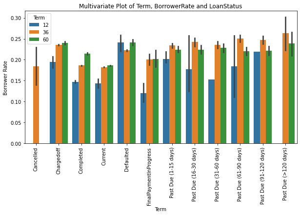

```python
plt.figure(figsize=(10,5))
sb.barplot(data=df_loan, x='LoanStatus',y='BorrowerRate',hue='Term');
labels('Multivariate Plot of Term, BorrowerRate and LoanStatus','Borrower Rate','Term')
plt.xticks(rotation=90);
```

### BorrowerRate vs LoanOriginalAmount vs LenderYield

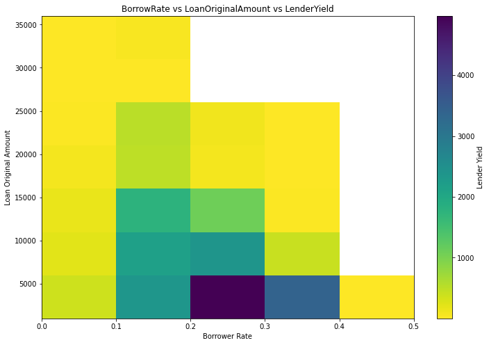

```python
bins_x = np.arange(0, 0.4925+0.1, 0.1)
bins_y = np.arange(1000, 35000+5000,5000)

plt.figure(figsize=(12,8))
plt.hist2d(data=df_loan, x='BorrowerRate', y='LoanOriginalAmount', cmin=0.5,cmap='viridis_r',
           bins=[bins_x,bins_y], weights=df_loan['LenderYield']);
labels('BorrowRate vs LoanOriginalAmount vs LenderYield','Loan Original Amount','Borrower Rate')
plt.colorbar(label='Lender Yield');
```

### BorrowerAPR Vs LoanStatus in each EmploymentStatus

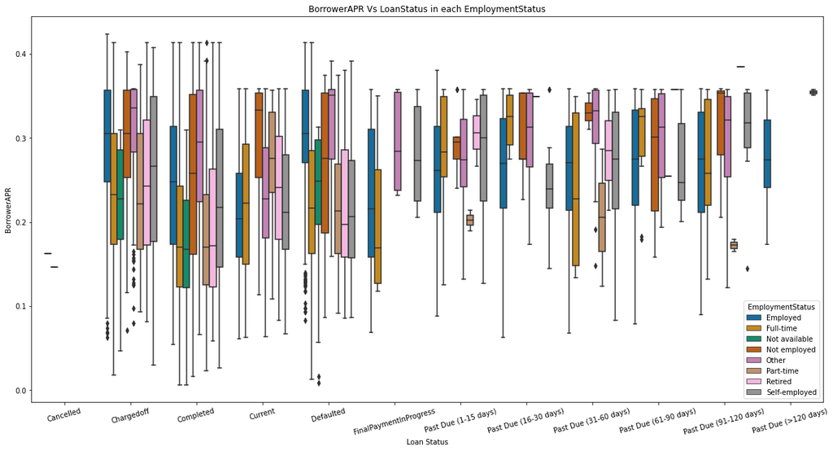

```python
plt.figure(figsize=(20,10))
sb.boxplot(data=df_loan, x='LoanStatus', y='BorrowerAPR', hue='EmploymentStatus', palette='colorblind');
labels('BorrowerAPR Vs LoanStatus in each EmploymentStatus','BorrowerAPR','Loan Status')
plt.xticks(rotation = 15);
```

### Were there any interesting or surprising interactions between features?

Large loans have relatively less annual interest rate from the borrower as there was a negative correlation between Loan Original Amount and Borrower APR.

Heatmap was created to find out that ProsperScore and BorrowerAPR were negatively correlated as higher the prosper score lower will be the risk attached hence lower will be the APR and that further lowers down the yield.

```python
#save dataframe for explanatory phase
df_loan.to_csv('new_prosper_loan.csv')
```

## Conclusions

Overall, we found that though business was amongst the top 3 reasons people take loan, self-employed people took less loans than people who are employed. We found that the higher the salary income does not affect taking a loan as people who earn 100k+ still make up a huge part of the population that collect loans while people who earned more were generally granted high loan amounts. Also, we saw people in California tend to take more loans and Professionals and Computer Programmers took more loans than people from other occupations. 3 years was also the most popular loan term as opposed to 5 years and 1 year.